# Causal Inference - Exercise DiD

Michael Knaus

SoSe 25

These are the goals of today:

- Replicate Stevenson and Wolfers’ (2006) to illustrate staggered difference-in-differences

# Staggered treatment adoption

```
if (!require("estimatr")) install.packages("estimatr", dependencies = TRUE); library(estimatr)
if (!require("tidyverse")) install.packages("tidyverse", dependencies = TRUE); library(tidyverse)
if (!require("did")) install.packages("did", dependencies = TRUE); library(did)
if (!require("haven")) install.packages("haven", dependencies = TRUE); library(haven)
if (!require("fixest")) install.packages("fixest", dependencies = TRUE); library(fixest)
if (!require("panelView")) install.packages("panelView", dependencies = TRUE); library(panelView)
if (!require("usmap")) install.packages("usmap", dependencies = TRUE); library(usmap)
```

Let’s set some `ggplot` defaults to save some space:

```
# Set the defaults for plotting:
custom_colors = c("#023E8A", "#FFB703")
options(ggplot2.discrete.colour = custom_colors)
options(ggplot2.discrete.fill = custom_colors)
update_geom_defaults("text", list(hjust = -0.1, vjust = -0.5, fontface = "bold"))

custom_theme = theme_grey(base_size = 12) +
  theme(plot.title = element_text(face = "bold", hjust = 0.5),
        legend.text = element_text(size = 8),
        legend.title = element_text(size = 10, face = "bold"),
        strip.text = element_text(size = 12))
theme_set(custom_theme)
```

## No-fault divorce reforms and female suicide

Now, we look at the case where a treatment is introduced at different times for different groups. We follow Stevenson and Wolfers’ (2006) study on no-fault divorce reforms and female suicide.

**Some background**: For a long time, divorce laws were pretty strict, especially for women. At one point, both partners had to agree to get a divorce, which meant if one person wanted out but the other didn’t, they had little to no legal recourse to leave the marriage. It was a tough spot to be in for people in unhappy or abusive marriages

But then, starting in the 60s and 70s, states began adopting what’s called unilateral divorce, where just one person could file for and get a divorce without needing the other’s consent. This was a huge change because it meant people—particularly women—could leave marriages they were trapped in before.

Stevenson and Wolfers study how different states adopted unilateral divorce laws gradually between 1969 and 1985, using the remaining states as controls to measure the impact on female suicide rates.

## Identification of ATT(g, t)

In the lecture, we defined the *group-time average treatment effect on the treated*:

$$ATT(g, t) = \mathbb{E}[Y_t(g) − Y_t(∞) \mid G = g]$$

which is the average treatment effect at time $t$ for the group of units first treated at time $g$*.*

Using ”never-treated” as the control group, we stated the parallel trends assumption as

$$\mathbb{E}[Y_t(∞) − Y_{t'} (∞) | G = g] = \mathbb{E}[Y_t(∞) −
Y_{t'} (∞) | G = ∞] \quad ∀ \quad t \neq t'$$

and the no anticipation assumption as
$$Y_t(g) = Y_t(∞) \quad ∀ \quad t < g$$

The $ATT(g,t)$ is then identified as
$$\begin{align*}
ATT(g,t) &= \mathbb{E}[Y_t(g) - Y_t(\infty) | G = g]
\overset{\text{cons.}}{=} \overbrace{\mathbb{E}[Y_t | G =
g]}^{\text{factual}} - \overbrace{\mathbb{E}[Y_t(\infty) | G =
g]}^{\text{counterfactual}} \\[1.5em]&= \mathbb{E}[Y_t | G = g] -
\{\mathbb{E}[Y_{g-1} | G = g] + \mathbb{E}[Y_t - Y_{g-1} | G = \infty]\}
\\[1.5em]&= \mathbb{E}[Y_t - Y_{g-1} | G = g] - \{\mathbb{E}[Y_t -
Y_{g-1} | G = \infty]\}
\end{align*}$$

Which is nothing more than a simple 2×2 difference-in-differences. In our case, various such DiDs could result in:

- $ATT(1969, 1969) = \mathbb{E}[Y_{1969} - Y_{1968} | G = g] - \{\mathbb{E}[Y_{1969} - Y_{1968} | G = \infty]\}$, the average effect for units in 1969 that are first treated in the same year ⇒ an instantaneous effect.
- $ATT(1969, 1979) = \mathbb{E}[Y_{1979} - Y_{1968} | G = g] - \{\mathbb{E}[Y_{1979} - Y_{1968} | G = \infty]\}$, the average effect for units in 1979 that are first treated in 1969 ⇒ a long term effect 10 years after treatment took place.

Callaway and Sant’Anna describe $ATT(g,t)$ as “building blocks” that are later combined to obtain a causal parameter of interest.

If we want to aggregate treatment effects $l$ periods after adoption across different cohorts, we end up with a weighted combination of simple 2×2 DiD estimators:

$$ATT_{l}^{W} = \sum_{g} w_{g} ATT(g, g + l) = \sum_{g} w_{g} ATT(g, t)$$

The choice of weights will be discussed in a moment.

## Get and prepare the data

We will use these variables:

- `asmrs` - suicide mortality per 1 million women
- `year` - time variable
- `G` - first treatment year (0 if never treated)
- `stfips` - unit identifier (state FIPS code)

```
# Getting the data
url = "https://www.damianclarke.net/stata/bacon_example.dta"
destfile = tempfile(fileext = ".dta")

download.file(url, destfile, mode = "wb")
```

```
versuche URL 'https://www.damianclarke.net/stata/bacon_example.dta'
```

```
data = read_dta(destfile)

data[, c("abbr", "full")] = fips_info(data$stfips)[, c(1, 3)]
data = data %>%
  group_by(stfips) %>%
  mutate(G = ifelse(any(post == 1), min(year[post == 1]), 0), # 1st treatment year
         event_time = year - G) %>% ungroup() # event time wrt to G
```

Let’s see how the policy was introduced using [panelView](https://yiqingxu.org/packages/panelview/index.html):

```
panelview(asmrs ~ post,
          data = data, index = c("full","year"), xlab = "Year", ylab = "State",
          by.timing = TRUE, pre.post = TRUE, cex.axis = 7, cex.legend = 10, axis.lab.angle=90,
          legend.labs = c("Control", "Treated (Pre)", "Treated (Post)"))
```

```
Specified labels in the order of: Controls, Treated (Pre), Treated (Post).
```

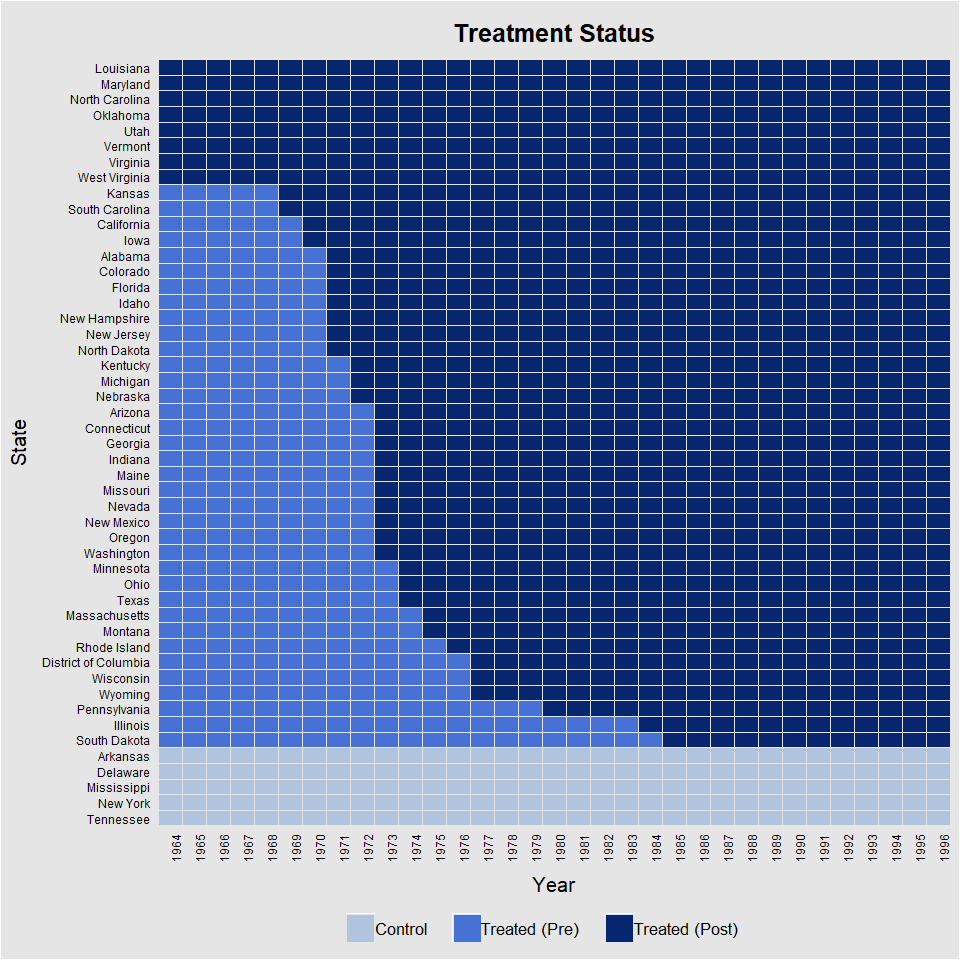

Most states become treated between 1970 and 1973, with a few states being ‘late’ or ‘early’ adopters.

One insight from the literature on staggered settings and two-way fixed effects regressions is that large variation in treatment timing may lead to bias: states that adopt the policy earlier (e.g., in 1970) serve as controls for states that adopted it later (e.g., in 1982).

We essentially compare treated units to other treated units at different periods, and if treatment effects change over time (as they often do in most real-world cases), we may run into problems. We will see if that’s a major issue in our case.

In the following, we will use the estimator by Callaway and Sant’Anna (2021). Before running the package, let’s try to recreate the results ourselves.

We begin by creating one of these $ATT(g, t)$ for states that underwent the reform in 1969. The effect we aim to estimate is 10 years post-treatment. Let’s start by pulling the data needed for a simple 2×2 DiD. For the treated, that would be:

```
g = 1969
l = 10 # t = g + l, l = horizon

post_year = g + l
pre_year  = g - 1

# Treated group
treated = data %>%
  filter(G == g & year %in% c(pre_year, post_year)) %>%
  mutate(period = ifelse(year == pre_year, "pre", "post")) %>%
  select(asmrs, full, year, G, event_time, period) %>% arrange(full)
treated
```

| asmrs | full | year | G | event_time | period |
| --- | --- | --- | --- | --- | --- |
| 59.65464 | Kansas | 1968 | 1969 | -1 | pre |
| 52.64465 | Kansas | 1979 | 1969 | 10 | post |
| 42.63845 | South Carolina | 1968 | 1969 | -1 | pre |
| 36.97046 | South Carolina | 1979 | 1969 | 10 | post |

Two states adopted unilateral divorce laws in 1969: Kansas and South Carolina. For the control units, we get:

```
# Control group
control = data %>%
  filter(G == 0 & year %in% c(pre_year, post_year)) %>%
  mutate(period = ifelse(year == pre_year, "pre", "post")) %>%
  select(asmrs, full, year, G, event_time, period) %>% arrange(full)
control
```

| asmrs | full | year | G | event_time | period |
| --- | --- | --- | --- | --- | --- |
| 33.50609 | Arkansas | 1968 | 0 | 1968 | pre |
| 42.91700 | Arkansas | 1979 | 0 | 1979 | post |
| 82.92950 | Delaware | 1968 | 0 | 1968 | pre |
| 33.09782 | Delaware | 1979 | 0 | 1979 | post |
| 34.31266 | Mississippi | 1968 | 0 | 1968 | pre |
| 49.19362 | Mississippi | 1979 | 0 | 1979 | post |
| 33.46987 | New York | 1968 | 0 | 1968 | pre |
| 43.37894 | New York | 1979 | 0 | 1979 | post |
| 42.75832 | Tennessee | 1968 | 0 | 1968 | pre |
| 62.48520 | Tennessee | 1979 | 0 | 1979 | post |

Since we use only never-treated units as our control group, each $ATT(g,t)$ will contain the same set of units to construct the counterfactual.

Now, we estimate a simple 2x2 DiD, as we did at the beginning:

```
treated_post = mean(treated$asmrs[treated$period == "post"])
treated_pre  = mean(treated$asmrs[treated$period == "pre" ])
control_post = mean(control$asmrs[control$period == "post"])
control_pre  = mean(control$asmrs[control$period == "pre" ])

att_g_t = (treated_post - treated_pre) - (control_post - control_pre)
cat("ATT(g,g+l) = ATT(1969, 1979) =", att_g_t, "\n")
```

```
ATT(g,g+l) = ATT(1969, 1979) = -7.15822
```

To obtain an event study coefficient, i.e., the average effect 10 years after treatment for treated states, we need to average this $ATT(g, g+l)$ across cohorts $g$:

```
# All treatment cohorts (excluding never-treated G=0 and always-treated G=1964)
treatment_cohorts = sort(unique(data$G[data$G > 0 & data$G != 1964]))
treatment_cohorts
```

```
 [1] 1969 1970 1971 1972 1973 1974 1975 1976 1977 1980 1984 1985
```

A final decision to make is the choice of $w_g$, the weights in $ATT_{l}^{W} = \sum_{g} w_{g} ATT(g, g + l)$. An intuitive approach would be to apply identical (uniform) weights to each $ATT(g,t)$.

In fact, Callaway and Sant’Anna do something else. The weights $w_g$ are chosen to reflect the relative frequency of units (states) first treated in each cohort: we give more weight to cohorts with a higher proportion of treated units. For example, If in the cohort of 1973 ten states adopt the policy, while in 1969 only two, the $ATT(g,t)$ estimated from the 1973 cohort receives a five times larger weight.

Intuitively, we are more confident if the estimate of $ATT(g,t)$ is based on more units within a cohort. The weights would be:

```
# Count number of states treated each year
data %>% filter(G > 0 & G != 1964) %>% distinct(stfips, G) %>%
  group_by(G) %>% summarise(tr_states = n()) %>% mutate(weight = tr_states / sum(tr_states))
```

| G | tr_states | weight |
| --- | --- | --- |
| 1969 | 2 | 0.05555556 |
| 1970 | 2 | 0.05555556 |
| 1971 | 7 | 0.19444444 |
| 1972 | 3 | 0.08333333 |
| 1973 | 10 | 0.27777778 |
| 1974 | 3 | 0.08333333 |
| 1975 | 2 | 0.05555556 |
| 1976 | 1 | 0.02777778 |
| 1977 | 3 | 0.08333333 |
| 1980 | 1 | 0.02777778 |

[output cut: 2 more lines]

Finally, we create a function that pulls the data to create 2x2 DiDs and loops over cohorts to estimate the group-time average treatment effect on the treated. It then aggregates these estimates according to the weights we defined.

```
# Function to compute ATT for a specific treatment group and time horizon
compute_att_for_group = function(data, g, horizon) {

  post_year = g + horizon
  pre_year  = g - 1

  # Compute Difference-in-Differences estimate
  treated = data %>%
    filter(G == g & year %in% c(pre_year, post_year)) %>%
    mutate(period = ifelse(year == pre_year, "pre", "post")) %>%
    select(asmrs, full, year, G, event_time, period) %>% arrange(full)

  control = data %>%
    filter(G == 0 & year %in% c(pre_year, post_year)) %>%
    mutate(period = ifelse(year == pre_year, "pre", "post")) %>%
    select(asmrs, full, year, G, event_time, period) %>% arrange(full)

  treated_post = mean(treated$asmrs[treated$period == "post"])
  treated_pre  = mean(treated$asmrs[treated$period == "pre" ])
  control_post = mean(control$asmrs[control$period == "post"])
  control_pre  = mean(control$asmrs[control$period == "pre" ])

  att_g_t = (treated_post - treated_pre) - (control_post - control_pre)
  return(list(att_g_t = att_g_t, g = g, horizon = horizon,
              n_treated = nrow(treated)/2, n_control = nrow(control)/2))
}

# Compute ATT for all treatment cohorts with year horizon
compute_att_l = function(data, horizon) {

  results_list = list()

  # Compute ATT for each cohort
  for(g in treatment_cohorts) {
    results_list[[length(results_list) + 1]] = compute_att_for_group(data, g, horizon)}

  results_df = bind_rows(lapply(results_list, function(x) {
    data.frame(g = x$g, horizon = x$horizon, att_g_t = x$att_g_t,
               n_treated = x$n_treated, n_control = x$n_control)}))

  # Calculate overall ATT(l): weighted average (by number of treated units)
    att_l = weighted.mean(results_df$att_g_t, w = results_df$n_treated)
    return(list(cohort_results = results_df, att_l = att_l))
}
```

This is the average effect of participating in the treatment 10 periods after it was adopted, across all groups that were ever observed to have participated in the treatment for exactly 10 periods:

```
results = compute_att_l(data, horizon = 10)
cat("ATT(l = 10):", results$att_l, "\n")
```

```
ATT(l = 10): -11.17722
```

Plotting its composition:

```
# A plot of cohort-specific ATTs
ggplot(results$cohort_results, aes(x = g, y = att_g_t)) + geom_point(aes(size = n_treated)) +
  geom_hline(yintercept = results$att_l, linetype = "dashed", color = "red") +
  labs(title = "Cohort-specific ATT(g,t) estimates", x = "Treatment cohort (G)",
       y = "ATT(g,t) estimate", size = "Treated units")
```

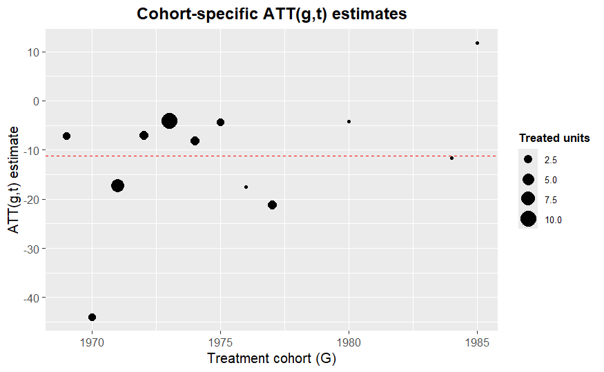

Now, we use the [did package](https://cran.r-project.org/web/packages/did/vignettes/did-basics.html) to estimate multiple pre- (post-) treatment effects:

```
cs_result = att_gt(
  yname = "asmrs",      # Outcome variable
  tname = "year",       # Time variable
  gname = "G",          # First treatment year (0 is never treated)
  idname = "stfips",    # Unit identifier (State FIPS code)
  data = data)
```

```
agg_effects = aggte(cs_result, type = "dynamic") # aggregate ATT(g,t)
summary(agg_effects)
```

```
Call:
aggte(MP = cs_result, type = "dynamic")

Reference: Callaway, Brantly and Pedro H.C. Sant'Anna.  "Difference-in-Differences with Multiple Time Periods." Journal of Econometrics, Vol. 225, No. 2, pp. 200-230, 2021. <https://doi.org/10.1016/j.jeconom.2020.12.001>, <https://arxiv.org/abs/1803.09015>


Overall summary of ATT's based on event-study/dynamic aggregation:
```

| ATT | Std. Error | [ 95% | Conf. Int.] |  |
| --- | --- | --- | --- | --- |
| -10.9024 | 3.3217 | -17.4128 | -4.3921 | * |

```
Dynamic Effects:
```

| Event time | Estimate | Std. Error | [95% Simult. | Conf. Band] |  |
| --- | --- | --- | --- | --- | --- |
| -20 | -4.0489 | 1.7343 | -8.9342 | 0.8364 |  |
| -19 | 16.7209 | 11.1764 | -14.7610 | 48.2029 |  |
| -18 | -7.3137 | 2.1716 | -13.4307 | -1.1967 | * |
| -17 | 2.8099 | 6.7327 | -16.1548 | 21.7746 |  |
| -16 | 3.0811 | 4.5987 | -9.8725 | 16.0347 |  |
| -15 | 4.3623 | 6.0225 | -12.6021 | 21.3268 |  |
| -14 | -0.0852 | 4.7808 | -13.5517 | 13.3814 |  |
| -13 | 1.0827 | 7.6496 | -20.4650 | 22.6304 |  |
| -12 | -1.1249 | 8.7230 | -25.6959 | 23.4462 |  |
| -11 | -11.3121 | 7.0319 | -31.1197 | 8.4956 |  |

[output cut: 38 more lines]

```
---
Signif. codes: `*' confidence band does not cover 0

Control Group:  Never Treated,  Anticipation Periods:  0
Estimation Method:  Doubly Robust
```

```
ggdid(agg_effects, xgap=3, title = "The effect of no-fault divorce on female suicide, ATT(l)",
      xlab = "Years relative to divorce reform", ylab = "Suicides per 1m women")
```

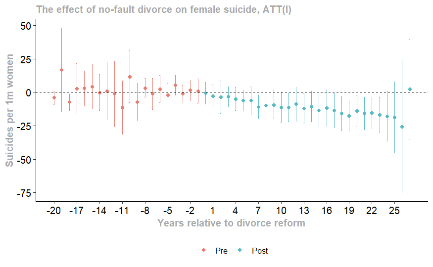

The first thing that may come to mind is: Wow, there are a lot of estimates!

Note that the coefficients for the 10th post-treatment period are identical to the manual computation:

```
all.equal(agg_effects[["att.egt"]][agg_effects[["egt"]] == l], results$att_l)
```

```
[1] TRUE
```

Having multiple pre-treatment periods allows us to examine pre-trend estimates: small coefficients would make the parallel trends argument more credible. (Remember that we cannot directly test the PT assumption since it applies specifically to post-treatment periods, so our pre-trend estimates are of the “wrong” period for testing the assumption itself.)

Another issue is that we usually have low power to detect PT violations: see [Roth (2022)](https://www.jonathandroth.com/assets/files/roth_pretrends_testing.pdf) for modern solutions.

Sometimes researchers ‘trim’ distant periods that may have less units to compare and lead to noisier estimates. We can limit the estimation window and average the effects over the eight years preceding and the fifteen years following the reform:

```
agg_trim = aggte(cs_result, type = "dynamic", min_e = -8, max_e = 15)
# summary(agg_trim)

ggdid(agg_trim, title = "The effect of no-fault divorce on female suicide , ATT(l) [trimmed]",
      xlab = "Years relative to divorce reform", ylab = "Suicides per 1m women")
```

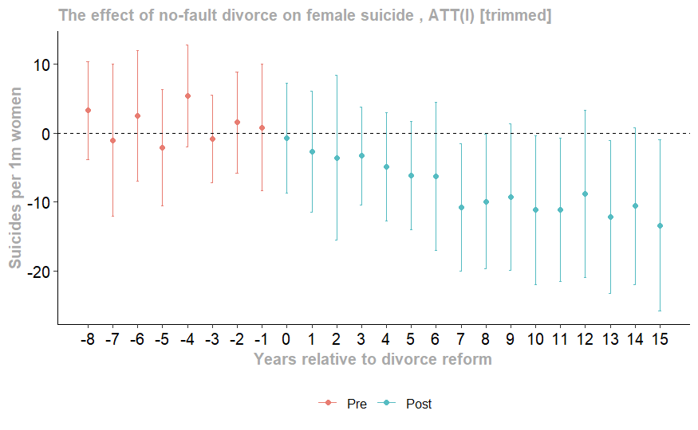

Note that the overall effect of participating in the treatment changes when omitting some periods:

```
print(rbind("ATT (no trim):" = agg_effects$overall.att,
            "ATT (trim):" = agg_trim$overall.att))
```

```
                     [,1]
ATT (no trim): -10.902414
ATT (trim):     -7.829474
```

This happens mechanically, as we average over fewer event study coefficients to obtain a single ATT:

```
all.equal(mean(agg_effects[["att.egt"]][agg_effects[["egt"]] >= 0]), agg_effects$overall.att)
```

```
[1] TRUE
```

```
all.equal(mean(agg_trim[["att.egt"]][agg_trim[["egt"]] >= 0]), agg_trim$overall.att)
```

```
[1] TRUE
```

In the lecture we focused on the case where only ”never-treated” are used as control group. We can identify the treatment effects in a similar fashion while relying on parallel trends for the “not yet treated” and treated groups:

$$\mathbb{E}[Y_t(∞)−Y_{t'}(∞)|G=g] =
\mathbb{E}[Y_t(∞)−Y_{t}(∞)|G=g'] \quad ∀ \quad t \neq t′ \quad
\text{and} \quad g \neq g'$$

Using “not yet treated” as controls requires assuming that their untreated potential outcomes follow the same trend as those of earlier-treated units before either group is treated.

The choice of the control group is application-specific and requires good substantive knowledge. Here, we contradict the authors just to illustrate the point:

```
cs_NotYet = att_gt(yname = "asmrs", tname = "year", gname = "G", idname = "stfips",
                    data = data, panel = TRUE, control_group = "notyettreated")

agg_NotYet = aggte(cs_NotYet, type = "dynamic", min_e = -8, max_e = 15)

# ggdid(agg_NotYet, title = "The effect of no-fault divorce on female suicide, ATT(l) [trimmed+NYT]", xlab = "Years relative to divorce reform", ylab = "Suicides per 1m women")

print(rbind("ATT (no trim):" = agg_effects$overall.att,
            "ATT (trim):" = agg_trim$overall.att,
            "ATT (trim+NYT):" = agg_NotYet$overall.att))
```

```
                      [,1]
ATT (no trim):  -10.902414
ATT (trim):      -7.829474
ATT (trim+NYT):  -5.400056
```

Overall, we find that the introduction of unilateral divorce led to a decline in female suicide in the states that adopted the policy.

If you had data on the outcome for different age groups, what would you expect to see? Would you be concerned if the effect held uniformly across different ages?

Finally, we compare the Callaway and Sant’Anna’s estimator to the naive two-way fixed effects regression:

```
# Get the data in the appropriate format
twfe_df = data %>%
  select(asmrs, stfips, year, event_time, G) %>% group_by(stfips) %>%
  mutate(event_time = ifelse(G == 0, -1000, event_time)) %>%
  filter((event_time >= -8 & event_time <= 15) | event_time == -1000)

# Run the Two-way fixed effects model
twfe = feols(asmrs ~ i(event_time, ref = c(-1, -1000)) | year + stfips, twfe_df)

plot_df = bind_rows(tidy(twfe) %>%
           mutate(event.time = as.numeric(str_remove(term, "event_time::")), method="TWFE"),
           tidy(agg_trim) %>% mutate(method = "Callaway & Sant’Anna"))

# Plot the result
ggplot(plot_df, aes(x = event.time, y = estimate, color = method, linetype = method)) +
  geom_point(size = 3) + geom_line() +
  geom_errorbar(aes(ymin = estimate - 1.96 * std.error, width = 0.2,
                    ymax = estimate + 1.96 * std.error), alpha = 0.8) +
  geom_vline(xintercept = -1, linetype = "dotted") +
  geom_hline(yintercept = 0, linetype = "dotted") +
  scale_color_manual(values = c("Callaway & Sant’Anna" = "darkred", "TWFE" = "grey50")) +
  theme_minimal(base_size = 14) + theme(legend.position = c(0.85, 0.95)) +
  labs(title = "TWFE vs. Callaway & Sant’Anna, ATT(l)", x = "Years to divorce reform",
       y = "Suicides per 1m women", color = NULL, linetype = NULL)
```

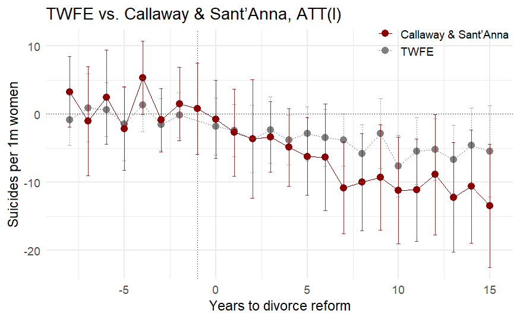

### (optional self-study)

1. Replicating the package results when ‘not-yet-treated’ are used as controls is harder, since the control group is now dynamic. Try writing a function that replicates a coefficient of the CS estimator using ‘not-yet-treated’ as controls.